# Exam

ISSU0053: Data Science and Big Data Analytics, Practice

This exam makes up 50% of the mark for this course.

Scheduling:

- Date: N/A
- Start time: N/A
- Duration: 2.5 hours

Examination conditions:

- This exam is to be completed under open-book conditions. You may consult your notes, teaching material, relevant online resources, etc.
- You are welcome to make use of R libraries which we have taught as part of the course. If you do make use of R libraries then the code to load those libraries must be included somewhere within your question answers.
- All work submitted must be your own. All forms of communication and messaging during the exam are strictly prohibited, and violations will be dealt with in accordance with UCL policy.
- You may work on the UCL computers, or on your own laptop. If you choose to work on your own laptop then you take responsibility for any technical issues.
- At the end of the exam you will have a short time to collate the files you have produced and upload them for marking.

Notes

- Partial marks may be awarded for code sections which have been completed, but which are non-functional.
- When answering questions, you should include units where relevant and quote values to an appropriate number of significant figures. Plots should be displayed with appropriate axes and labels.
- Marks for questions are indicative, and may be transformed to generate a final grade.

```r
library(cvTools)
library(tidyverse)
```

# Section A

An analysis of crab body dimensions.

Male fiddler crabs have one large claw (used to attract females) and one small claw. These are classified as the major and minor claws, respectively. Major claws can be either on the right or the left.

The data in the file `crab.csv` contains the following measurements taken from male crabs sampled from a large colony.

- `crab.id` an ID number for the measurement.
- `body.size` the size of the crab’s body in cm.
- `major.claw` the size of the crab’s major claw in cm.
- `minor.claw` the size of the crab’s minor claw in cm.
- `claw.ratio` the ration of the claw sizes (major/minor).
- `major.side` which side the major claw is on (left or right).

We wish to explore the data, and in particular to be able to determine an expected body size given the values of other measurements.

## Question 1

### Part i

State your student number.

0 marks

### Part ii

Is this an example of constructing a model for inference or for prediction?

1 mark

prediction

### Part iii

Write R code to read the `crabs.csv` file into your environment.

1 mark

```r
read.csv("crabs.csv")
```

[output not shown]

[output cut: 39 more lines]

If you are unable to complete this, you can instead load the data directly using the command below.

```r
load("crabs.Rda")
```

### Part iv

How many rows are in the dataset?

1 mark

```r
crabs <- read.csv("crabs.csv")
nrow(crabs)
```

```
[1] 49
```

What is the mean body size of the crabs sampled?

1 mark

```r
mean(crabs$body.size)
```

```
[1] 7.866327
```

### Part vi

What is the median size of the major claws recorded?

1 mark

```r
median(crabs$major.claw)
```

```
[1] 8.82
```

### Part vii

What percentage of the crabs in the dataset had their major claw on the right hand side?

1 mark

```r
count <- crabs$major.side == "Right"
sum(count)/nrow(crabs) * 100
```

```
[1] 42.85714
```

## Question 2

### Part i

Produce a scatter plot showing body size against major claw size.  
Ensure that the axes are labelled as “body size (cm)” and “major claw size (cm)”, and that the plot has the title “Body measurements of crabs”.

4 marks

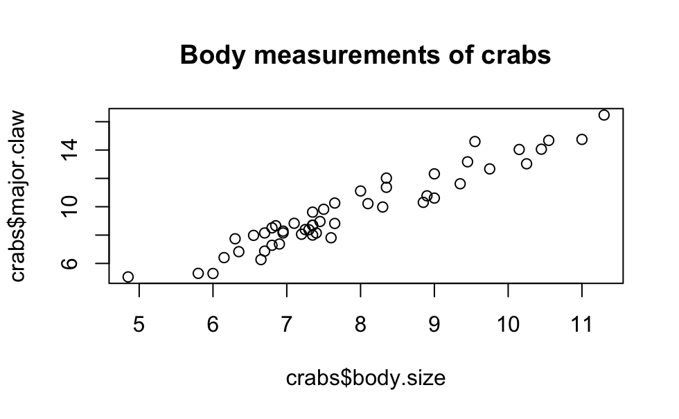

```r
plot(crabs$body.size, crabs$major.claw, main = "Body measurements of crabs")
```

### Part ii

Construct a linear regression model for the outcome body size, using major claw size as the covariate.

1 mark

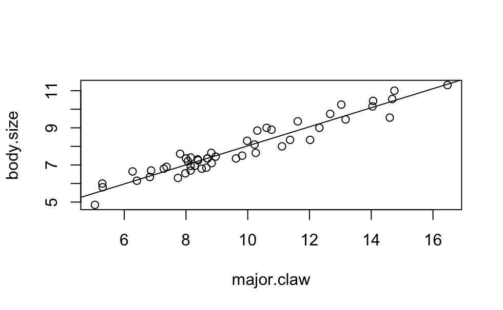

```r
linear = lm(body.size ~ major.claw, data=crabs)
plot(body.size~major.claw, data=crabs)
abline(linear)
```

### Part iii

Discuss how we can interpret the value for the fitted coefficient for major claw size.

1 mark

```r
summary(linear)
```

```
Call:
lm(formula = body.size ~ major.claw, data = crabs)

Residuals:
     Min       1Q   Median       3Q      Max
-0.84027 -0.37993 -0.00708  0.32007  0.69457

Coefficients:
            Estimate Std. Error t value Pr(>|t|)
(Intercept)  2.89711    0.21908   13.22   <2e-16 ***
major.claw   0.51323    0.02179   23.55   <2e-16 ***
---
Signif. codes:  0 ‘***’ 0.001 ‘**’ 0.01 ‘*’ 0.05 ‘.’ 0.1 ‘ ’ 1

Residual standard error: 0.4131 on 47 degrees of freedom
Multiple R-squared:  0.9219,    Adjusted R-squared:  0.9202
F-statistic: 554.7 on 1 and 47 DF,  p-value: < 2.2e-16
```

### Part iv

Use the results of the fitted model to predict the mean body size of crabs which have a major claw size equal to 10cm.

1 mark

```r
library(tidyverse)
new <- crabs %>%
  filter(major.claw >= 10 & major.claw<= 11)

predict = predict(linear, new)
predict
```

```
       1        2        3        4        5
8.162848 8.142319 8.188509 8.424595 8.342479
```

## Question 3

Crabs are able to regrow a lost claw. It is proposed that this may lead to outliers, as claws in the process of regrowing will not be at their final size.

### Part i

On the scatter plot you created in Question 2 Part ii there is one point (with claw size approximately 7cm) that appears to be an outlier to the fit.

Identify the row index for this outlier, and use this to find its exact body size and claw size.

2 marks

```r
crabs %>%
  filter(major.claw<=8 & body.size>=8)
```

| crab.id | body.size | major.claw | minor.claw | claw.ratio | major.side | log_body.size | log_major.claw |
| --- | --- | --- | --- | --- | --- | --- | --- |

### Part ii

Is the position of this outlier consistent with the hypothesis that this crab is in the process of regrowing a lost claw? Explain your answer.

2 marks

```r
crabs %>%
  filter(body.size>=7 & body.size<=8)
```

| crab.id | body.size | major.claw | minor.claw | claw.ratio | major.side | log_body.size | log_major.claw |
| --- | --- | --- | --- | --- | --- | --- | --- |
| 38 | 7.10 | 8.83 | 2.38 | 3.71 | Right | 1.960095 | 2.178155 |
| 18 | 7.20 | 8.06 | 2.81 | 2.87 | Left | 1.974081 | 2.086914 |
| 24 | 7.25 | 8.39 | 3.20 | 2.62 | Right | 1.981001 | 2.127041 |
| 45 | 7.30 | 8.38 | 2.44 | 3.43 | Right | 1.987874 | 2.125848 |
| 20 | 7.35 | 8.70 | 2.74 | 3.18 | Right | 1.994700 | 2.163323 |
| 21 | 7.35 | 8.00 | 3.00 | 2.67 | Left | 1.994700 | 2.079442 |
| 40 | 7.35 | 9.62 | 2.44 | 3.94 | Right | 1.994700 | 2.263844 |
| 43 | 7.35 | 8.69 | 2.58 | 3.37 | Left | 1.994700 | 2.162173 |
| 50 | 7.40 | 8.15 | 2.65 | 3.08 | Left | 2.001480 | 2.098018 |
| 41 | 7.45 | 8.96 | 2.76 | 3.25 | Left | 2.008214 | 2.192770 |

[output cut: 5 more lines]

Yes, as crabs of similar body sizes have higher claw size, hence it may be that the particular crab is regrowing its claw hence a lower claw size.

### Part iii

Use R to remove the data row associated with this outlier from the data set.

1 mark

```r
crabs <- crabs%>%
  filter(crab.id!= 25)
crabs
```

[output not shown]

[output cut: 39 more lines]

## Question 4

### Part i

Calculate the coefficient of Pearson’s correlation, $r$, between the measurements of major and minor claw sizes.

1 mark

```r
correlation <- cor(crabs$major.claw, crabs$minor.claw, method = 'pearson')
 correlation
```

```
[1] 0.9264432
```

### Part ii

Explain why including both of these variables as covariates in a linear regression model to predict body size could be problematic.

1 mark As they are strongly related, it means that it is difficult to change one variable without changing another making it difficult to estimate the relationship between each independent variable.

### Part iii

It is proposed instead to use claw ratio in the model, to avoid such problems. Build a linear regression model for the outcome body size using the two variables major claw size and claw ratio as covariates.

1 mark

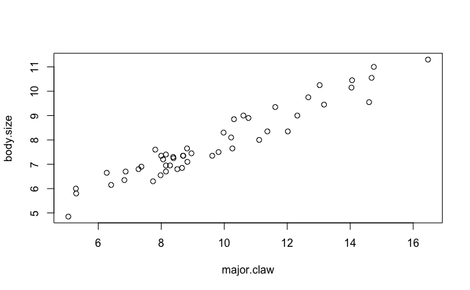

```r
model <- lm(body.size~ major.claw+ claw.ratio, data=crabs)
plot(body.size~major.claw + claw.ratio, data=crabs)
```

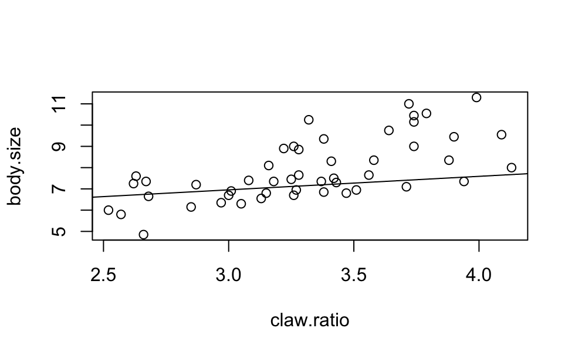

```r
abline(model)
```

### Part iv

Examine the fit of the resulting model. Look at the reported $F$-statistic value. What does this reported $F$-statistic relate to?

1 mark

```r
summary(model)
```

```
Call:
lm(formula = body.size ~ major.claw + claw.ratio, data = crabs)

Residuals:
    Min      1Q  Median      3Q     Max
-0.7402 -0.1623 -0.0222  0.2578  0.5473

Coefficients:
            Estimate Std. Error t value Pr(>|t|)
(Intercept)  5.04226    0.42731  11.800 1.63e-15 ***
major.claw   0.63792    0.02846  22.413  < 2e-16 ***
claw.ratio  -1.01115    0.18434  -5.485 1.70e-06 ***
---
Signif. codes:  0 ‘***’ 0.001 ‘**’ 0.01 ‘*’ 0.05 ‘.’ 0.1 ‘ ’ 1

Residual standard error: 0.3247 on 46 degrees of freedom
Multiple R-squared:  0.9528,    Adjusted R-squared:  0.9507
F-statistic: 464.1 on 2 and 46 DF,  p-value: < 2.2e-16
```

The high F-stat value indicates that it is effective in explaining the variance in the body size.

### Part v

In this case, what does result arising from the $F$-statistic tell us? Explain your answer.

1 mark large F-stat

larger F-statistic indicates a greater disparity between the variances, suggesting that the model explains a significant portion of the variability in the data. If the F-statistic is significantly large, it suggests that the null hypothesis can be rejected, indicating that the groups means are not all equal or the model coefficients are not all zero.

### Part vi

Construct a linear regression model which adds major side as a third predictor.

1 mark

```r
model1 <- lm(body.size~ major.claw+ claw.ratio + major.side, data=crabs)
```

### Part vii

Is there evidence that including this predictor improves the model? Explain your answer.

2 marks

```r
anova(model,model1)
```

```
Analysis of Variance Table

Model 1: body.size ~ major.claw + claw.ratio
Model 2: body.size ~ major.claw + claw.ratio + major.side
  Res.Df    RSS Df Sum of Sq      F Pr(>F)
1     46 4.8498
2     45 4.8146  1  0.035243 0.3294 0.5689
```

- not stat significant bec p-value is >0.05. Hence by adding major.side does not improve the model.
- or compare R-square

## Question 5

All parts of this question consider the explanation of body size using major claw size only.

### Part i

To estimate the range of R-squared values that might arise from fitting to different samples of the population, we will resample the data 100 times in a bootstrap analysis. For each resample we will fit the simple linear regression model and therefore we will end up with 100 measurements of the R-squared fit values.

Note: The R-squared value can be extracted directly from the summary of the fitted model. For example, if the model is `lm.1` then `rsq <- summary(lm.1)$r.squared` stores only the R-squared value.

Carry out this analysis, for example using a for loop to generate a bootstrapped dataset, fit the simple linear regression model of body size using the covariate major claw size, store the resulting value of R-squared, and repeat this looping until 100 bootstrap measurments have been obtained.

4 marks

```r
library(boot)
library(dplyr)

rsquare <- rep(0,100)

for(i in 1:100){
  bootstrap_data <- sample_n(crabs, size = 20, replace = T)
  lm.1 = lm(body.size~ major.claw, data=bootstrap_data)
  rsquare[i] <- summary(lm.1)$r.squared
}
print(rsquare)
```

```
  [1] 0.9600661 0.9366429 0.9507766 0.9655124 0.9566424 0.8762245 0.9247581 0.9514541
  [9] 0.9501245 0.9279315 0.9213934 0.9160952 0.9141589 0.9420262 0.9023270 0.9190741
 [17] 0.9327039 0.9321027 0.9444943 0.9420597 0.9043360 0.8987795 0.9134883 0.9461881
 [25] 0.8942148 0.9162224 0.8968080 0.9224657 0.9215717 0.9342089 0.9325230 0.9341023
 [33] 0.9183380 0.9374605 0.9483301 0.9166112 0.9352200 0.9264065 0.8538841 0.9405220
 [41] 0.9281733 0.9174474 0.9193007 0.9252470 0.8984177 0.8432617 0.9099302 0.9282761
 [49] 0.9645560 0.9263371 0.9149216 0.9138915 0.9105449 0.9137182 0.9199617 0.8996954
 [57] 0.8865550 0.9667515 0.9391801 0.9660661 0.8476268 0.8796703 0.8693044 0.9253740
 [65] 0.9014115 0.9430160 0.9520993 0.8547048 0.9146582 0.8368968 0.9648239 0.9553970
 [73] 0.8910604 0.8704668 0.9303168 0.9603138 0.9248639 0.8750421 0.9283291 0.9124043
 [81] 0.8720511 0.9213151 0.9206406 0.9208643 0.9102427 0.9399652 0.9467821 0.9386610
 [89] 0.9432418 0.9540357 0.9426809 0.9200069 0.9120639 0.9255419 0.9307887 0.8646727
 [97] 0.9056022 0.9258504 0.8833200 0.9295846
```

### Part ii

Make a histogram of the resulting distribution of the R-squared values. Use appropriate axes labels.

2 marks

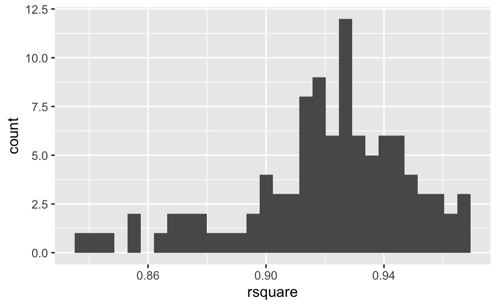

```r
library(tidyverse)
r2 = data.frame(r2 = rsquare)
ggplot(data = r2, mapping = aes(x=rsquare),binwidth=1) +
  geom_histogram()
```

### Part iii

It is proposed that a fit of log(body size) against log(major claw size) will better describe the data in comparison to using the non-transformed measurements.

Create new columns in the data frame which store the log measurements of body size and major claw size.

2 marks

```r
crabs <- crabs %>%
  mutate(log_body.size = log(body.size),
         log_major.claw = log(major.claw))
```

### Part iv

Perform the linear regression using the log transformed measurements and examine the fit results.

1 mark

```r
library(texreg)
model3<-lm(log_body.size ~ log_major.claw, data=crabs )
screenreg(list(model3, linear))
```

```
====================================
                Model 1    Model 2
------------------------------------
(Intercept)      0.67 ***   2.90 ***
                (0.06)     (0.22)
log_major.claw   0.62 ***
                (0.03)
major.claw                  0.51 ***
                           (0.02)
------------------------------------
R^2              0.91       0.92
Adj. R^2         0.91       0.92
Num. obs.       49         49
====================================
*** p < 0.001; ** p < 0.01; * p < 0.05
```

### Part v

Evaluate whether using log transformations makes the fit of the model for body size using major claw size significantly better, significantly worse, or is not significantly different compared to the original model.

2 marks

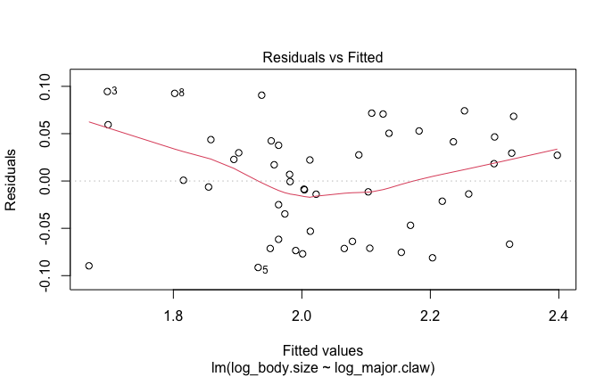

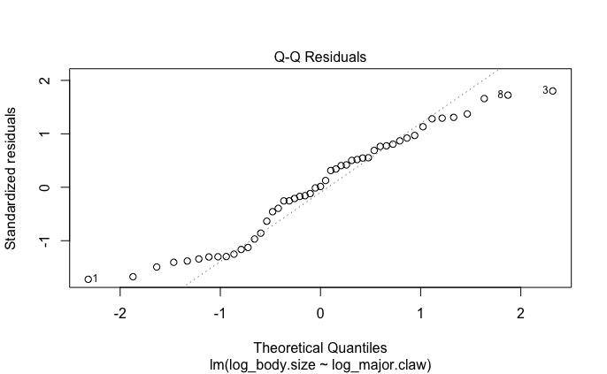

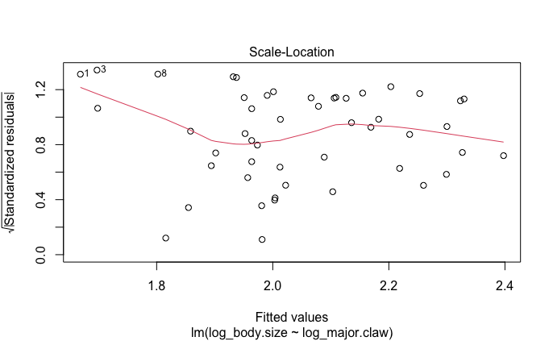

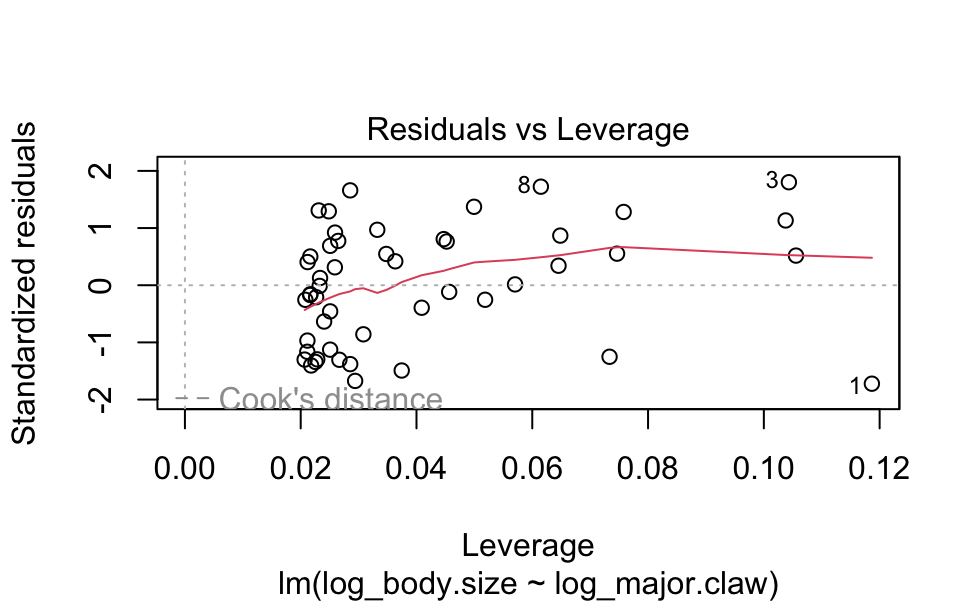

```r
plot(model3)
```

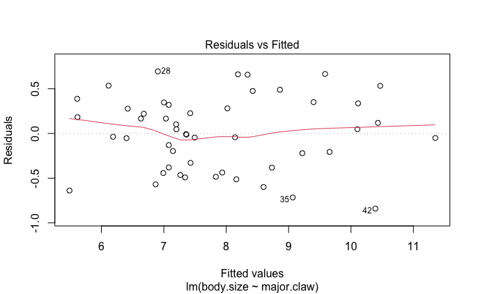

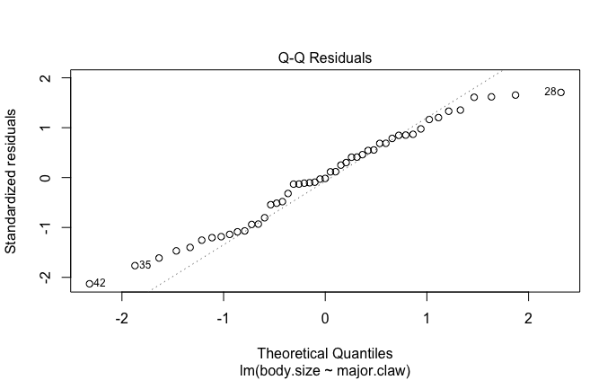

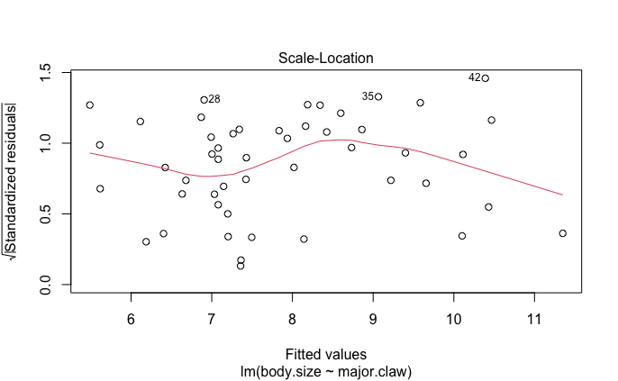

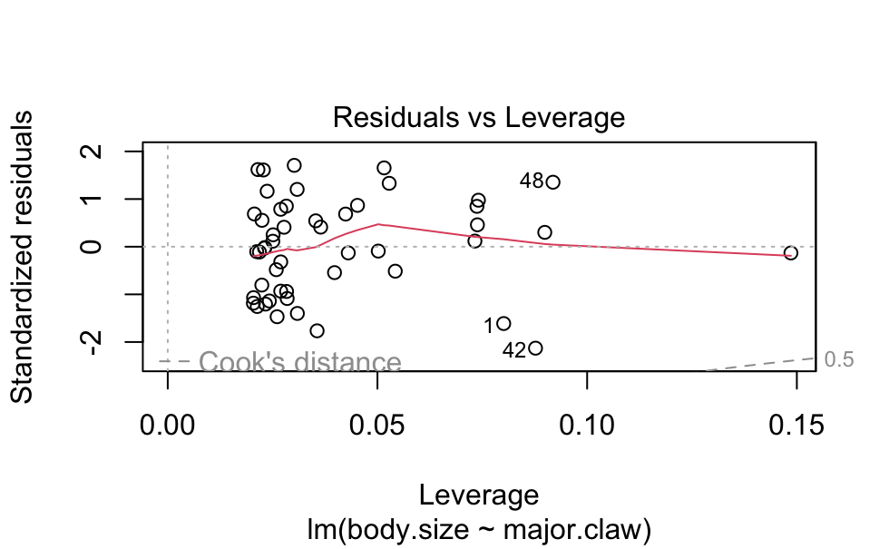

```r
plot(linear)
```

# Section B

This consists of an analysis of mortality (death rates) based upon demographic information from metropolitan areas in the USA.

The file `mortality.csv` stores the following columns:

- `A1` Average January rainfall in inches
- `A2` Average January temperature in degrees Fahrenheit
- `A3` Average July temperature in degrees Fahrenheit
- `A4` Percent of population aged 65 or older
- `A5` Average household size in 1960
- `A6` Average level of schooling for persons over 22
- `A7` Percentage of households with full kitchens
- `A8` Population per square mile in urbanized areas
- `A9` Percent non-white population
- `A10` Percent office workers
- `A11` Poor families (income under $3000)
- `A12` Relative pollution level of hydrocarbons
- `A13` Relative pollution level of Nitrogen Oxides
- `A14` Relative pollution level of Sulphur Dioxide
- `A15` Percent relative humidity
- `B` Total annual age-adjusted mortality rate per 100 000 members of the population

This data was collected as part of an investigation to determine how air pollution and other factors are related to death rates.

## Question 6

### Part i

Write R code to load the data into your environment.

1 mark

```r
mortality = read.csv("mortality.csv")
```

If you are unable to complete this, you can instead load the data directly using the command below.

```r
load("crabs.Rda")
```

### Part ii

Examine the correlation between predictors and the response, identifying the predictors which have a strong positive (above +0.5) correlation with mortality rate.

1 mark

```r
#install.packages("GGally")
library(GGally)
matrix <- cor(mortality, use = "complete.obs")
which(matrix[,'B'] > 0.5)
```

```
A1 A9  B
 1  9 16
```

A1 , A9

### Part iii

Examine the correlation between predictors and the response, identifying the predictors which have a strong negative (below -0.5) correlation with mortality rate.

1 mark

```r
matrix <- cor(mortality, use = "complete.obs")
which(matrix[,'B'] < -0.5)
```

```
A6
 6
```

### Part iv

Fit a multiple linear regression model to predict the death rate, `B`, using all possible predictors, `A1` to `A15`.

1 mark

```r
mutiple = lm(B~ . , data=mortality)
```

### Part v

Fidn the predicted death rate in each area according to the fitted model and store the values into a new column.

1 mark

```r
pred <- predict(mutiple)
mortality %>%
  mutate(pred)
```

| A1 | A2 | A3 | A4 | A5 | A6 | A7 | A8 | A9 | A10 | A11 | A12 | A13 | A14 | A15 | B | pred |
| --- | --- | --- | --- | --- | --- | --- | --- | --- | --- | --- | --- | --- | --- | --- | --- | --- |
| 36 | 27 | 71 | 8.1 | 3.34 | 11.4 | 81.5 | 3243 | 8.8 | 42.6 | 11.7 | 21 | 15 | 59 | 59 | 921.870 | 936.4745 |
| 35 | 23 | 72 | 11.1 | 3.14 | 11.0 | 78.8 | 4281 | 3.6 | 50.7 | 14.4 | 8 | 10 | 39 | 57 | 997.875 | 932.8874 |
| 44 | 29 | 74 | 10.4 | 3.21 | 9.8 | 81.6 | 4260 | 0.8 | 39.4 | 12.4 | 6 | 6 | 33 | 54 | 962.354 | 936.8156 |
| 47 | 45 | 79 | 6.5 | 3.41 | 11.1 | 77.5 | 3125 | 27.1 | 50.2 | 20.6 | 18 | 8 | 24 | 56 | 982.291 | 982.6836 |
| 43 | 35 | 77 | 7.6 | 3.44 | 9.6 | 84.6 | 6441 | 24.4 | 43.7 | 14.3 | 43 | 38 | 206 | 55 | 1071.289 | 1056.7986 |
| 53 | 45 | 80 | 7.7 | 3.45 | 10.2 | 66.8 | 3325 | 38.5 | 43.1 | 25.5 | 30 | 32 | 72 | 54 | 1030.380 | 1076.1892 |
| 43 | 30 | 74 | 10.9 | 3.23 | 12.1 | 83.9 | 4679 | 3.5 | 49.2 | 11.3 | 21 | 32 | 62 | 56 | 934.700 | 918.6679 |
| 45 | 30 | 73 | 9.3 | 3.29 | 10.6 | 86.0 | 2140 | 5.3 | 40.4 | 10.5 | 6 | 4 | 4 | 56 | 899.529 | 914.2756 |
| 36 | 24 | 70 | 9.0 | 3.31 | 10.5 | 83.2 | 6582 | 8.1 | 42.5 | 12.6 | 18 | 12 | 37 | 61 | 1001.902 | 986.6764 |
| 36 | 27 | 72 | 9.5 | 3.36 | 10.7 | 79.3 | 4213 | 6.7 | 41.0 | 13.2 | 12 | 7 | 20 | 59 | 912.347 | 927.4661 |

[output cut: 50 more lines]

### Part vi

Make a plot showing actual death rate on the $y$-axis and predicted death rate on the $x$-axis. Add a line showing how a prefect prediction would perform.

3 marks

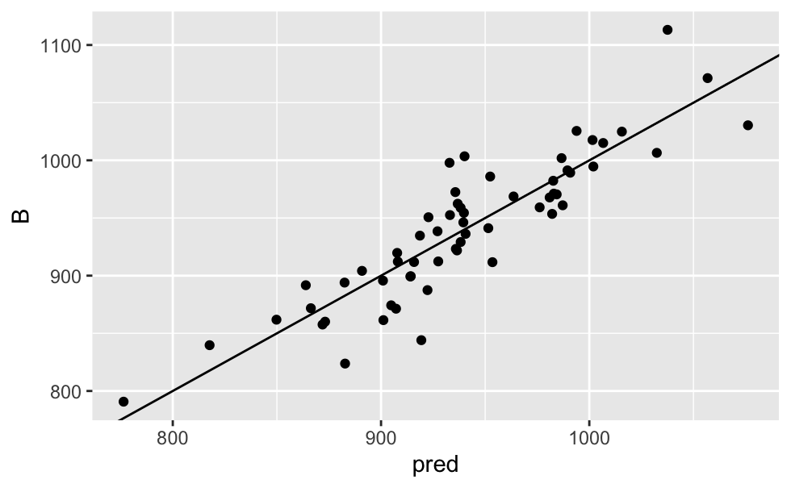

```r
mortality%>%
  ggplot(aes(x=pred, y=B))+
  geom_point()+
  geom_abline()
```

### Part vii

Examine the diagnostic plots for the fitted model by calling the `plot` command on the model. Identify the data row which has been flagged as having a high leverage.

1 mark

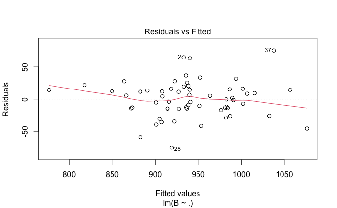

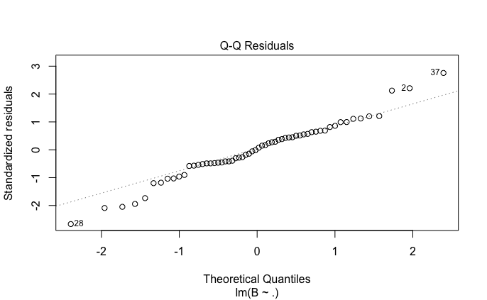

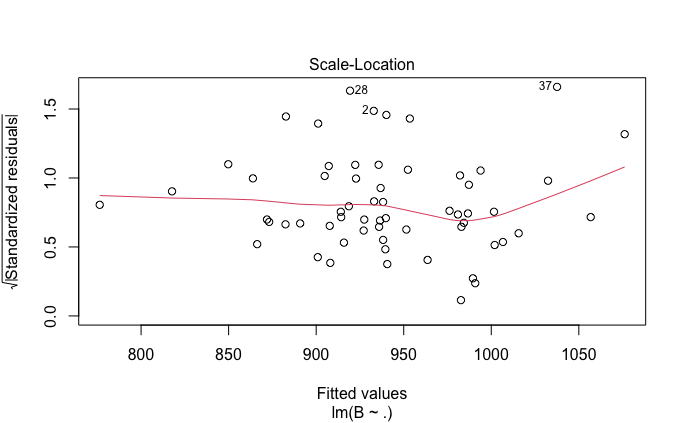

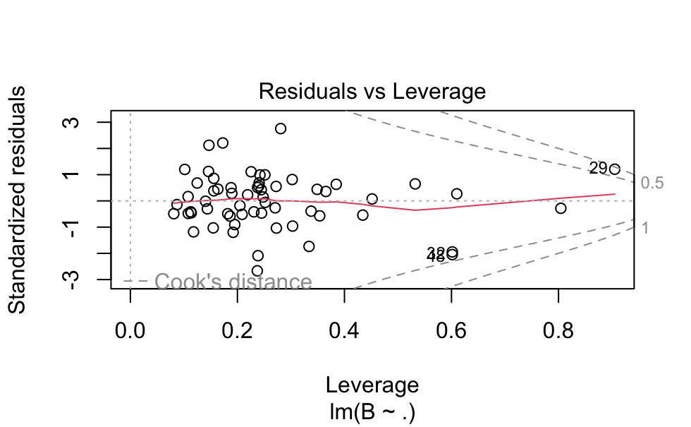

```r
plot(mutiple)
```

29

### Part viii

Find the data associated with the high leverage observation and suggest why this observation produces an outlier when used to predict the death rate.

1 mark

```r
nrow(mortality)
```

```
[1] 60
```

```r
rownames(mortality) = c(1:60)
mortality[29, ]
```

|  | A1 | A2 | A3 | A4 | A5 | A6 | A7 | A8 | A9 | A10 | A11 | A12 | A13 | A14 | A15 | B |
| --- | --- | --- | --- | --- | --- | --- | --- | --- | --- | --- | --- | --- | --- | --- | --- | --- |
| 29 | 11 | 53 | 68 | 9.2 | 2.99 | 12.1 | 90.6 | 4700 | 7.8 | 48.9 | 12.3 | 648 | 319 | 130 | 47 | 861.833 |